# Base de dados de leitos

Abner_10415165

22/01/2021

```r
library(tidyverse)
```

Temos 3 bancos de dados a serem usados Série antiga (variação mensal), Série antiga (variaçõa semanal) e Série em uso (variaçõa semanal e Grande São Paulo unificada)

# Série antiga (variação mensal)

```r
leitos1<-read.csv2("https://raw.githubusercontent.com/seade-R/dados-covid-sp/master/data/plano_sp_leitos_internacoes_serie_nova.csv",
                   encoding = "UTF-8")
```

## Começo e fim da Séries

```r
leitos1$datahora<-as.Date(leitos1$datahora)

max(leitos1$datahora)
```

```
## [1] "2021-01-27"
```

```r
min(leitos1$datahora)
```

```
## [1] "2020-10-08"
```

Os dados estão atualizados porem o começo de sua série é apartir do dia 8 do mes de outubro de 2020.

## Os drs do banco de dados

```r
unique(leitos1$nome_drs)
```

```
##  [1] "DRS 01 Grande São Paulo"      "DRS 02 Araçatuba"
##  [3] "DRS 03 Araraquara"            "DRS 04 Baixada Santista"
##  [5] "DRS 05 Barretos"              "DRS 06 Bauru"
##  [7] "DRS 07 Campinas"              "DRS 08 Franca"
##  [9] "DRS 09 Marília"               "DRS 10 Piracicaba"
## [11] "DRS 11 Presidente Prudente"   "DRS 12 Registro"
## [13] "DRS 13 Ribeirão Preto"        "DRS 14 São João da Boa Vista"
## [15] "DRS 15 São José do Rio Preto" "DRS 16 Sorocaba"
## [17] "DRS 17 Taubaté"               "Estado de São Paulo"
```

Temos dados sobre 17 drs e o estado de são paulo

## Variável “pacientes_uti_mm7d”

Descrição: Média móvel para 7 dias do Pacientes Internados em Leitos de UTI Destinados para COVID-19 no dia

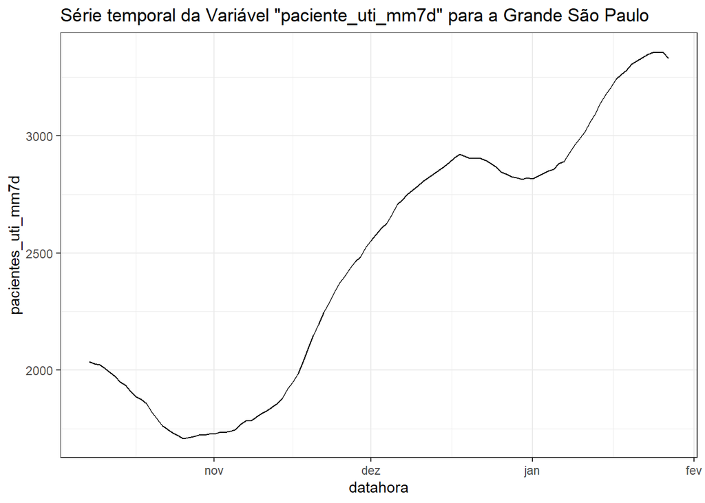

```r
leitos1 %>%
  filter(nome_drs=="DRS 01 Grande São Paulo") %>%
ggplot(aes(x=datahora,y=pacientes_uti_mm7d))+
  geom_line()+
  ggtitle("Série temporal da Variável \"paciente_uti_mm7d\" para a Grande São Paulo")+
  theme_bw()
```

## Variável “total_covid_uti_mm7d”

Descrição: Média móvel para 7 dias do Total de Leitos de UTI Destinados para COVID-19 no dia

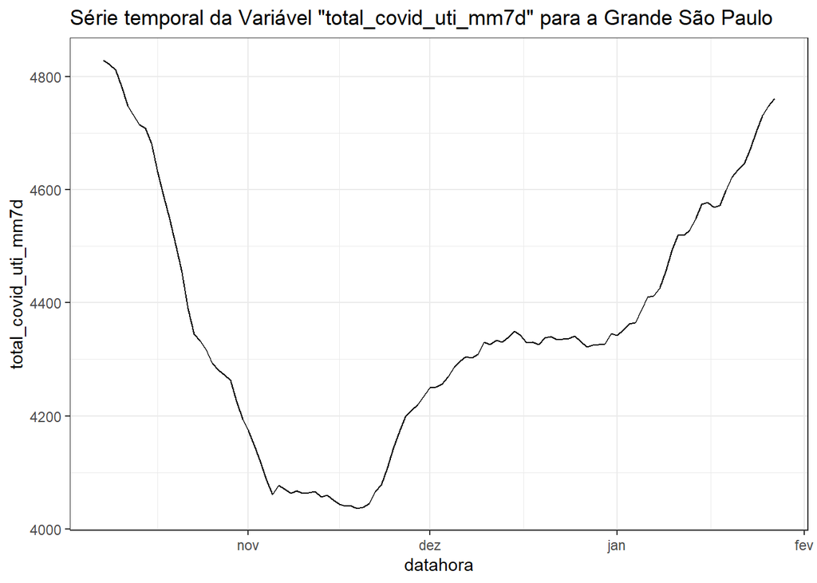

```r
leitos1 %>%
  filter(nome_drs=="DRS 01 Grande São Paulo") %>%
  ggplot(aes(x=datahora,y=total_covid_uti_mm7d))+
  geom_line()+
  ggtitle("Série temporal da Variável \"total_covid_uti_mm7d\" para a Grande São Paulo")+
  theme_bw()
```

## Variável “ocupacao_leitos”

Descrição: Ocupação de leitos de UTI destinados para COVID-19 (pacientes_uti_mm7d / total_covid_uti_mm7d)

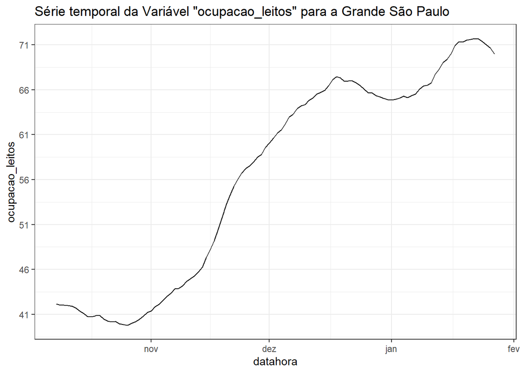

```r
leitos1 %>%
  filter(nome_drs=="DRS 01 Grande São Paulo") %>%
  ggplot(aes(x=datahora,y=ocupacao_leitos))+
  geom_line()+
  ggtitle("Série temporal da Variável \"ocupacao_leitos\" para a Grande São Paulo")+
  theme_bw()+
  scale_y_continuous(breaks=seq(1,100,5))
```

## Variável pop

Descrição: População da DRS ou região da Grande São Paulo (Fonte: SEADE).

É uma informação estatica porem no banco de dados ela se repete para cada dia.

```r
filtro<-leitos1 %>%
  filter(datahora==max(leitos1$datahora)) %>%
  select(nome_drs,pop)
filtro
```

```
##                        nome_drs      pop
## 1       DRS 01 Grande São Paulo 21138247
## 2              DRS 02 Araçatuba   764041
## 3             DRS 03 Araraquara   991435
## 4       DRS 04 Baixada Santista  1831884
## 5               DRS 05 Barretos   425090
## 6                  DRS 06 Bauru  1741281
## 7               DRS 07 Campinas  4562125
## 8                 DRS 08 Franca   696336
## 9                DRS 09 Marília  1109670
## 10            DRS 10 Piracicaba  1539600
## 11   DRS 11 Presidente Prudente   752260
## 12              DRS 12 Registro   278754
## 13        DRS 13 Ribeirão Preto  1477530
## 14 DRS 14 São João da Boa Vista   809836
## 15 DRS 15 São José do Rio Preto  1570421
## 16              DRS 16 Sorocaba  2461760
## 17               DRS 17 Taubaté  2489629
## 18          Estado de São Paulo 44639899
```

## Variável leitos_pc

Descrição: Leitos Covid-19 UTI por 100 mil habitantes (total_covid_uti_mm7d/pop)

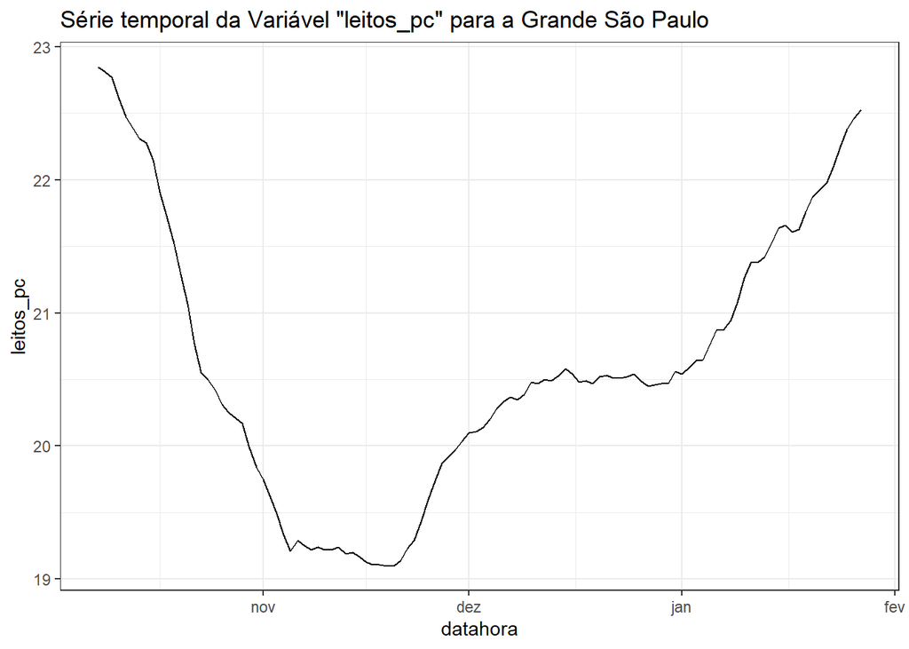

```r
leitos1 %>%
  filter(nome_drs=="DRS 01 Grande São Paulo") %>%
  ggplot(aes(x=datahora,y=leitos_pc))+
  geom_line()+
  ggtitle("Série temporal da Variável \"leitos_pc\" para a Grande São Paulo")+
  theme_bw()
```

## Variável internacoes_28d

Descrição: Número de novas internações (UTI e Enfermaria) de pacientes confirmados ou com suspeita de COVID-19 nos últimos 28 dias

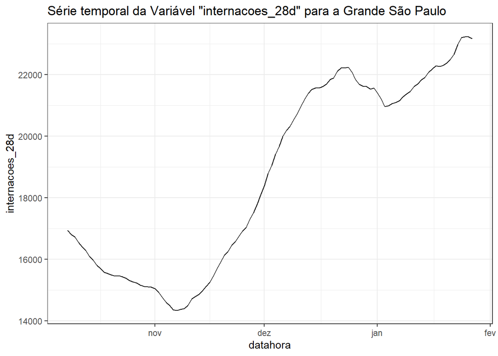

```r
leitos1 %>%
  filter(nome_drs=="DRS 01 Grande São Paulo") %>%
  ggplot(aes(x=datahora,y=internacoes_28d))+
  geom_line()+
  ggtitle("Série temporal da Variável \"internacoes_28d\" para a Grande São Paulo")+
  theme_bw()
```

## Variável internacoes_28d_l

Descrição: Número de novas internações (UTI e Enfermaria) de pacientes confirmados ou com suspeita de COVID-19 nos 28 dias anteriores

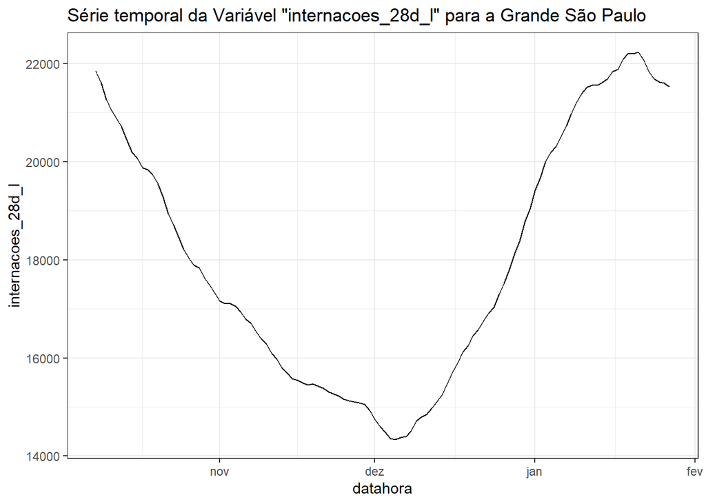

```r
leitos1 %>%
  filter(nome_drs=="DRS 01 Grande São Paulo") %>%
  ggplot(aes(x=datahora,y=internacoes_28d_l))+
  geom_line()+
  ggtitle("Série temporal da Variável \"internacoes_28d_l\" para a Grande São Paulo")+
  theme_bw()
```

## Variável internacoes_28v28

Descrição: Variação no número de novas internações ((internacoes_28d - internacoes_28d_l) / internacoes_28d_l)

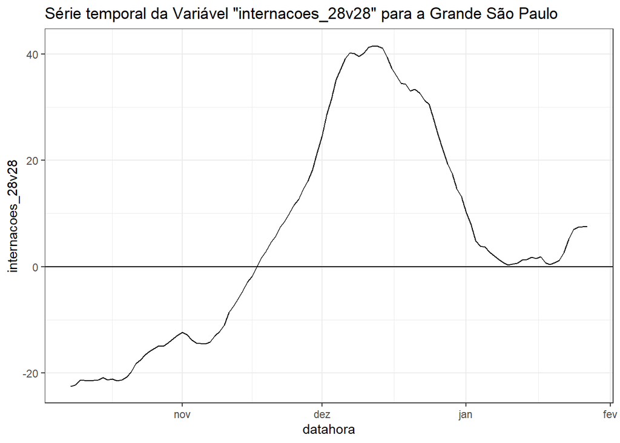

```r
leitos1 %>%
  filter(nome_drs=="DRS 01 Grande São Paulo") %>%
  ggplot(aes(x=datahora,y=internacoes_28v28))+
  geom_line()+
  ggtitle("Série temporal da Variável \"internacoes_28v28\" para a Grande São Paulo")+
  theme_bw()+
  geom_hline(yintercept = 0)
```

# Série antiga (variaçõa semanal)

```r
leitos2<-read.csv2("https://raw.githubusercontent.com/seade-R/dados-covid-sp/master/data/plano_sp_leitos_internacoes.csv",
                   encoding = "UTF-8")
```

## Começo e fim das Séries

```r
leitos2$datahora<-as.Date(leitos2$datahora)

min(leitos2$datahora)
```

```
## [1] "2020-05-19"
```

```r
max(leitos2$datahora)
```

```
## [1] "2021-01-27"
```

Os dados estão atualizados e começam apartir do dia 19 do mês 5 de 2020.

## Os drs do banco de dados

```r
unique(leitos2$nome_drs)
```

```
##  [1] "Município de São Paulo"       "Grande SP Leste"
##  [3] "Grande SP Norte"              "Grande SP Oeste"
##  [5] "Grande SP Sudeste"            "Grande SP Sudoeste"
##  [7] "DRS 02 Araçatuba"             "DRS 03 Araraquara"
##  [9] "DRS 04 Baixada Santista"      "DRS 05 Barretos"
## [11] "DRS 06 Bauru"                 "DRS 07 Campinas"
## [13] "DRS 08 Franca"                "DRS 09 Marília"
## [15] "DRS 10 Piracicaba"            "DRS 11 Presidente Prudente"
## [17] "DRS 12 Registro"              "DRS 13 Ribeirão Preto"
## [19] "DRS 14 São João da Boa Vista" "DRS 15 São José do Rio Preto"
## [21] "DRS 16 Sorocaba"              "DRS 17 Taubaté"
## [23] "Estado de São Paulo"
```

## Variável “pacientes_uti_mm7d”

Descrição: Média móvel para 7 dias do Pacientes Internados em Leitos de UTI Destinados para COVID-19 no dia.

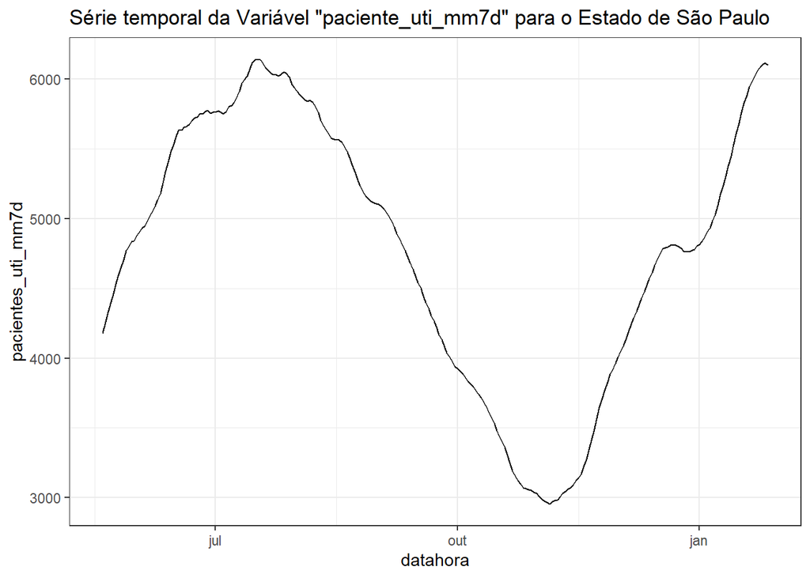

```r
leitos2 %>%
  filter(nome_drs=="Estado de São Paulo") %>%
  ggplot(aes(x=datahora,y=pacientes_uti_mm7d))+
  geom_line()+
  ggtitle("Série temporal da Variável \"paciente_uti_mm7d\" para o Estado de São Paulo")+
  theme_bw()
```

## Variável “total_covid_uti_mm7d”

Descrição: Média móvel para 7 dias do Total de Leitos de UTI Destinados para COVID-19 no dia.

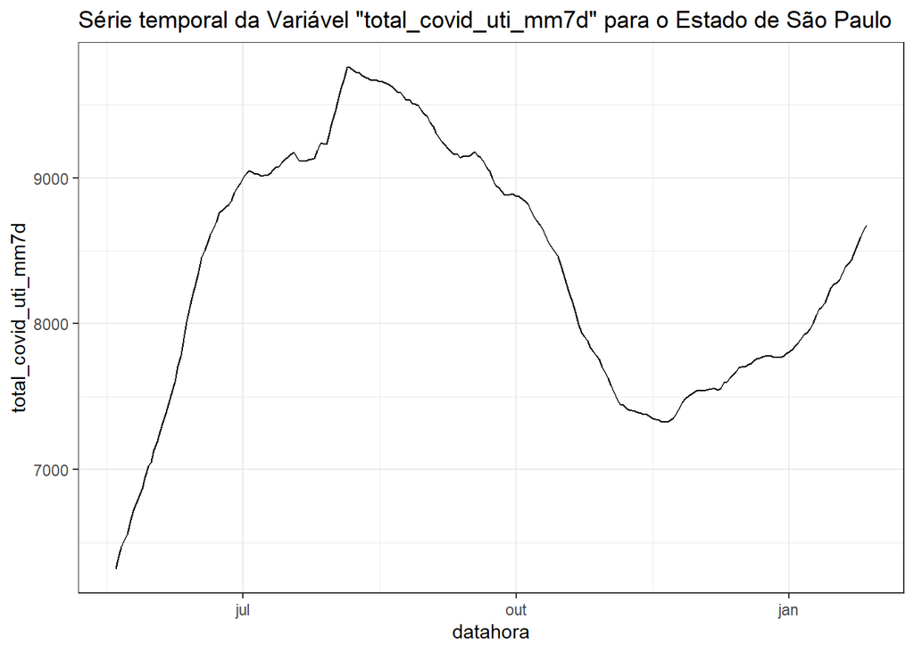

```r
leitos2 %>%
  filter(nome_drs=="Estado de São Paulo") %>%
  ggplot(aes(x=datahora,y=total_covid_uti_mm7d))+
  geom_line()+
  ggtitle("Série temporal da Variável \"total_covid_uti_mm7d\" para o Estado de São Paulo")+
  theme_bw()
```

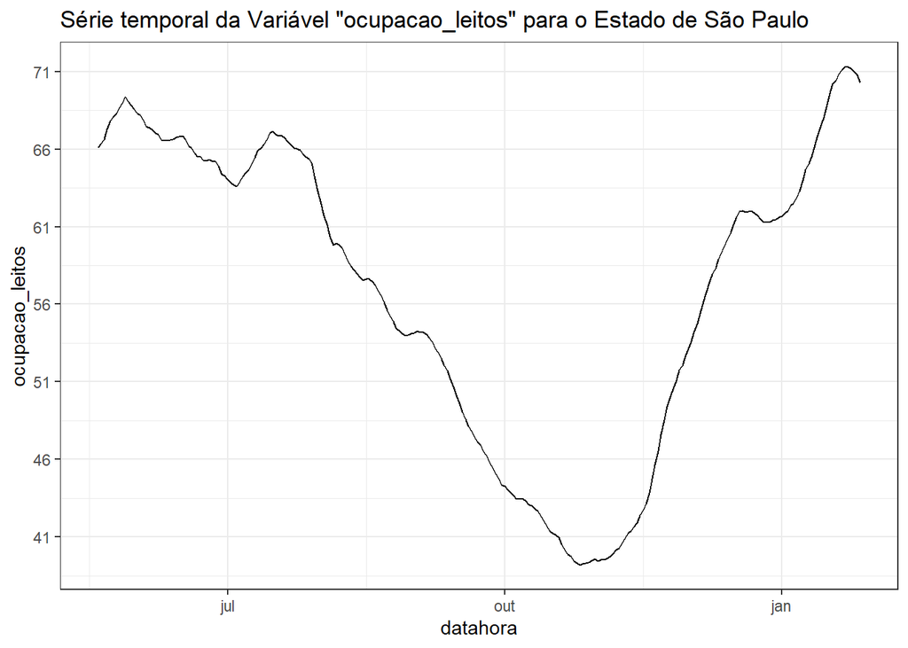

```r
leitos2 %>%
  filter(nome_drs=="Estado de São Paulo") %>%
  ggplot(aes(x=datahora,y=ocupacao_leitos))+
  geom_line()+
  ggtitle("Série temporal da Variável \"ocupacao_leitos\" para o Estado de São Paulo")+
  theme_bw()+
  scale_y_continuous(breaks=seq(1,100,5))
```

## Variável pop

Descrição: População da DRS ou região da Grande São Paulo (Fonte: SEADE).

É uma informação estatica porem no banco de dados ela se repete para cada dia

```r
filtro<-leitos2 %>%
  filter(datahora==max(leitos2$datahora)) %>%
  select(nome_drs,pop)
filtro
```

```
##                        nome_drs      pop
## 1        Município de São Paulo 11869660
## 2               Grande SP Leste  2977781
## 3               Grande SP Norte   603465
## 4               Grande SP Oeste  1858252
## 5             Grande SP Sudeste  2690590
## 6            Grande SP Sudoeste  1138499
## 7              DRS 02 Araçatuba   764041
## 8             DRS 03 Araraquara   991435
## 9       DRS 04 Baixada Santista  1831884
## 10              DRS 05 Barretos   425090
## 11                 DRS 06 Bauru  1741281
## 12              DRS 07 Campinas  4562125
## 13                DRS 08 Franca   696336
## 14               DRS 09 Marília  1109670
## 15            DRS 10 Piracicaba  1539600
## 16   DRS 11 Presidente Prudente   752260
## 17              DRS 12 Registro   278754
## 18        DRS 13 Ribeirão Preto  1477530
## 19 DRS 14 São João da Boa Vista   809836
## 20 DRS 15 São José do Rio Preto  1570421
## 21              DRS 16 Sorocaba  2461760
## 22               DRS 17 Taubaté  2489629
## 23          Estado de São Paulo 44639899
```

## Variável leitos_pc

Descrição: Leitos Covid-19 UTI por 100 mil habitantes (total_covid_uti_mm7d/pop)

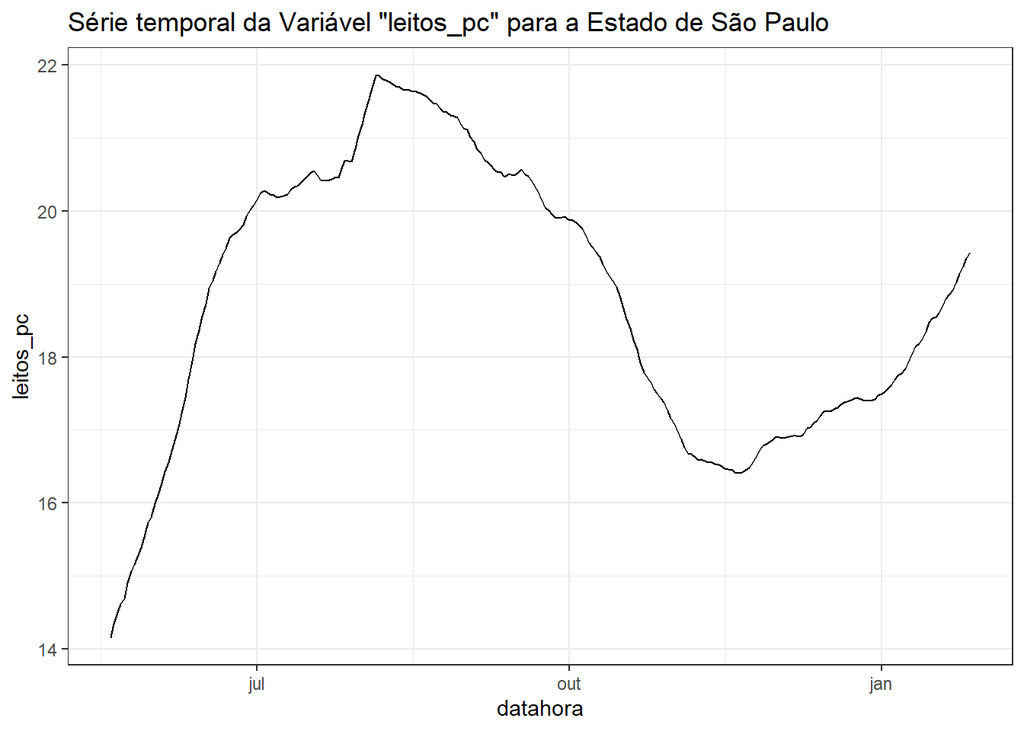

```r
leitos2 %>%
  filter(nome_drs=="Estado de São Paulo") %>%
  ggplot(aes(x=datahora,y=leitos_pc))+
  geom_line()+
  ggtitle("Série temporal da Variável \"leitos_pc\" para a Estado de São Paulo")+
  theme_bw()
```

## Variável internacoes_7d

Descrição: Número de novas internações (UTI e Enfermaria) de pacientes confirmados ou com suspeita de COVID-19 nos últimos 7 dias.

[figure not shown]

```r
leitos2 %>%
  filter(nome_drs=="Estado de São Paulo") %>%
  ggplot(aes(x=datahora,y=internacoes_7d))+
  geom_line()+
  ggtitle("Série temporal da Variável \"internacoes_7d\" para a Grande São Paulo")+
  theme_bw()
```

## Variável internacoes_7d_l

Descrição: Número de novas internações (UTI e Enfermaria) de pacientes confirmados ou com suspeita de COVID-19 nos 7 dias anteriores.

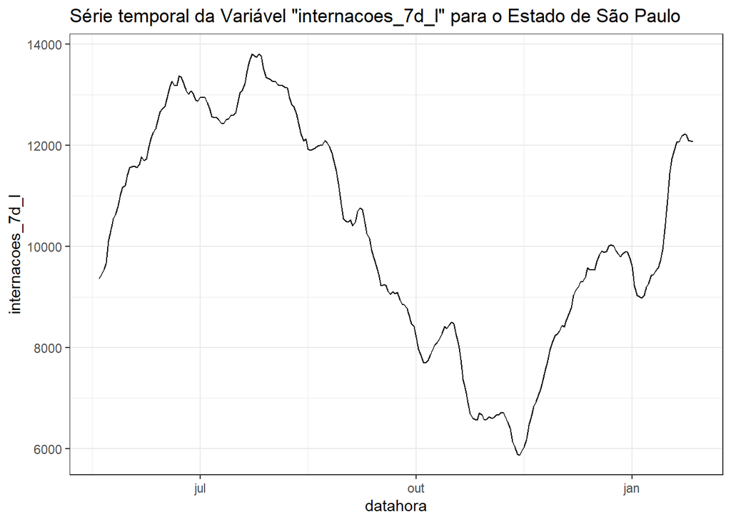

```r
leitos2 %>%
  filter(nome_drs=="Estado de São Paulo") %>%
  ggplot(aes(x=datahora,y=internacoes_7d_l))+
  geom_line()+
  ggtitle("Série temporal da Variável \"internacoes_7d_l\" para o Estado de São Paulo")+
  theme_bw()
```

## Variável internacoes_7v7

Variação no número de novas internações ((internacoes_7d - internacoes_7d_l) / internacoes_7d_l)

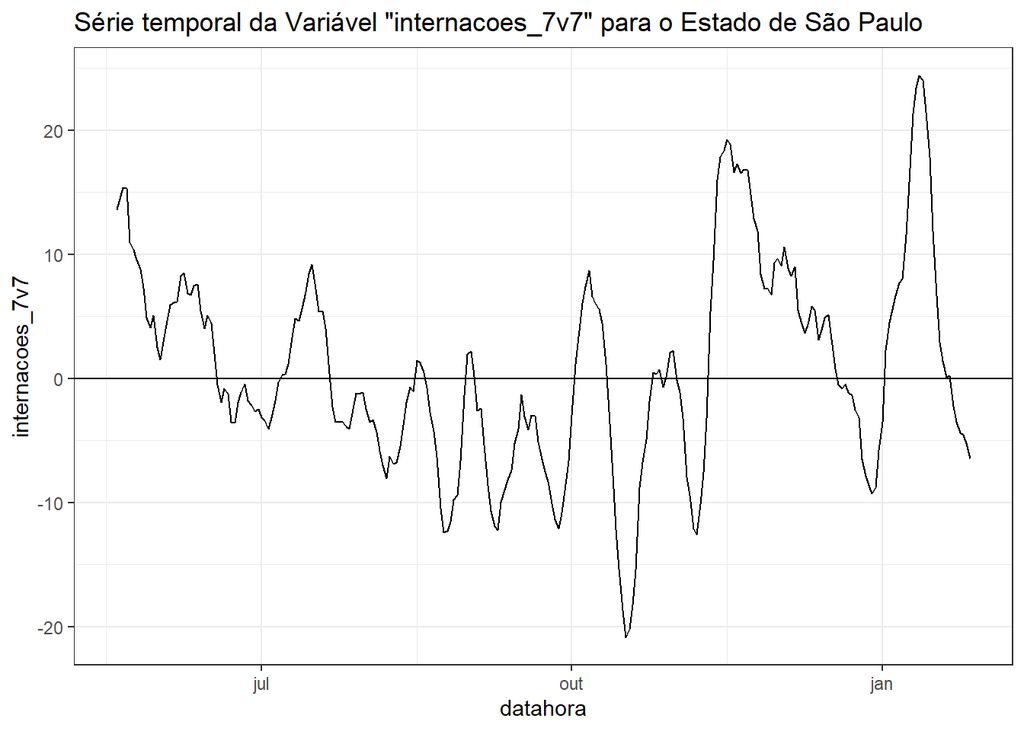

```r
leitos2 %>%
  filter(nome_drs=="Estado de São Paulo") %>%
  ggplot(aes(x=datahora,y=internacoes_7v7))+
  geom_line()+
  ggtitle("Série temporal da Variável \"internacoes_7v7\" para o Estado de São Paulo")+
  theme_bw()+
  geom_hline(yintercept = 0)
```

# Série em uso (variaçõa semanal e Grande São Paulo unificada)

```r
leitos3<-read.csv2("https://raw.githubusercontent.com/seade-R/dados-covid-sp/master/data/plano_sp_leitos_internacoes_serie_nova_variacao_semanal.csv",
                   encoding = "UTF-8")
```

## Começo e fim das Séries

```r
leitos3$datahora<-as.Date(leitos3$datahora)

min(leitos3$datahora)
```

```
## [1] "2020-10-08"
```

```r
max(leitos3$datahora)
```

```
## [1] "2021-01-27"
```

Os dados estão atualizados porem o começo de sua série é apartir do dia 8 do mes de outubro de 2020.

## Os drs do banco de dados

```r
unique(leitos3$nome_drs)
```

```
##  [1] "DRS 01 Grande São Paulo"      "DRS 02 Araçatuba"
##  [3] "DRS 03 Araraquara"            "DRS 04 Baixada Santista"
##  [5] "DRS 05 Barretos"              "DRS 06 Bauru"
##  [7] "DRS 07 Campinas"              "DRS 08 Franca"
##  [9] "DRS 09 Marília"               "DRS 10 Piracicaba"
## [11] "DRS 11 Presidente Prudente"   "DRS 12 Registro"
## [13] "DRS 13 Ribeirão Preto"        "DRS 14 São João da Boa Vista"
## [15] "DRS 15 São José do Rio Preto" "DRS 16 Sorocaba"
## [17] "DRS 17 Taubaté"               "Estado de São Paulo"
```

Temos dados sobre 17 drs e o estado de são paulo

## Variável “pacientes_uti_mm7d”

Descrição: Média móvel para 7 dias do Pacientes Internados em Leitos de UTI Destinados para COVID-19 no dia.

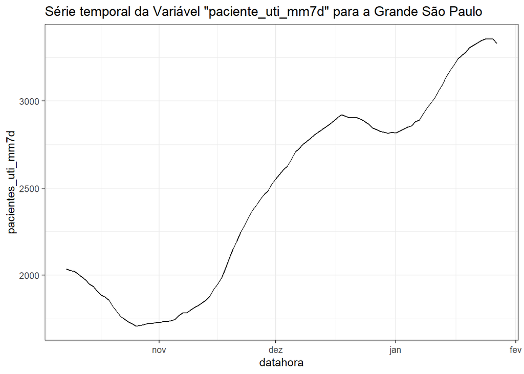

```r
leitos3 %>%
  filter(nome_drs=="DRS 01 Grande São Paulo") %>%
  ggplot(aes(x=datahora,y=pacientes_uti_mm7d))+
  geom_line()+
  ggtitle("Série temporal da Variável \"paciente_uti_mm7d\" para a Grande São Paulo")+
  theme_bw()
```

## Variável “total_covid_uti_mm7d”

Descrição: Média móvel para 7 dias do Total de Leitos de UTI Destinados para COVID-19 no dia

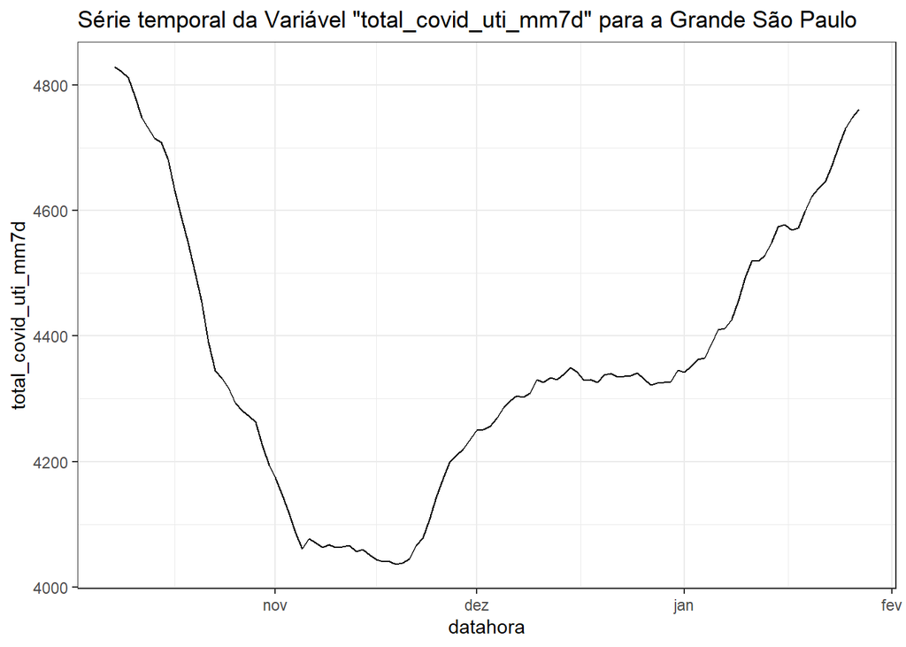

```r
leitos3 %>%
  filter(nome_drs=="DRS 01 Grande São Paulo") %>%
  ggplot(aes(x=datahora,y=total_covid_uti_mm7d))+
  geom_line()+
  ggtitle("Série temporal da Variável \"total_covid_uti_mm7d\" para a Grande São Paulo")+
  theme_bw()
```

## Variável “ocupacao_leitos”

Descrição: Ocupação de leitos de UTI destinados para COVID-19 (pacientes_uti_mm7d / total_covid_uti_mm7d)

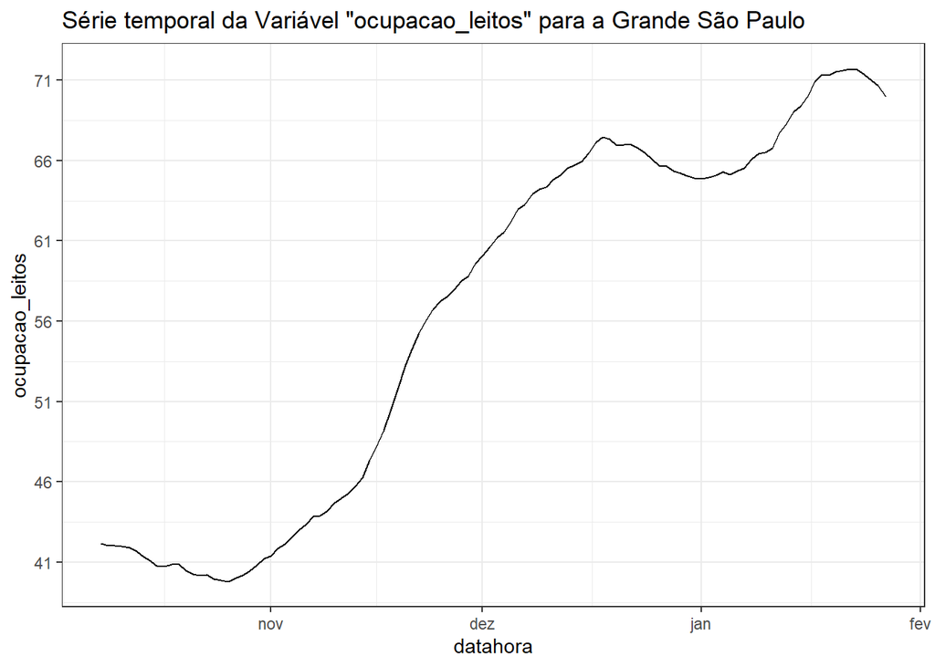

```r
leitos3 %>%
  filter(nome_drs=="DRS 01 Grande São Paulo") %>%
  ggplot(aes(x=datahora,y=ocupacao_leitos))+
  geom_line()+
  ggtitle("Série temporal da Variável \"ocupacao_leitos\" para a Grande São Paulo")+
  theme_bw()+
  scale_y_continuous(breaks=seq(1,100,5))
```

## Variável pop

Descrição: População da DRS ou região da Grande São Paulo (Fonte: SEADE).

É uma informação estatica porem no banco de dados ela se repete para cada dia.

```r
filtro<-leitos3 %>%
  filter(datahora==max(leitos3$datahora)) %>%
  select(nome_drs,pop)
filtro
```

```
##                        nome_drs      pop
## 1       DRS 01 Grande São Paulo 21138247
## 2              DRS 02 Araçatuba   764041
## 3             DRS 03 Araraquara   991435
## 4       DRS 04 Baixada Santista  1831884
## 5               DRS 05 Barretos   425090
## 6                  DRS 06 Bauru  1741281
## 7               DRS 07 Campinas  4562125
## 8                 DRS 08 Franca   696336
## 9                DRS 09 Marília  1109670
## 10            DRS 10 Piracicaba  1539600
## 11   DRS 11 Presidente Prudente   752260
## 12              DRS 12 Registro   278754
## 13        DRS 13 Ribeirão Preto  1477530
## 14 DRS 14 São João da Boa Vista   809836
## 15 DRS 15 São José do Rio Preto  1570421
## 16              DRS 16 Sorocaba  2461760
## 17               DRS 17 Taubaté  2489629
## 18          Estado de São Paulo 44639899
```

## Variável leitos_pc

Descrição: Leitos Covid-19 UTI por 100 mil habitantes (total_covid_uti_mm7d/pop)

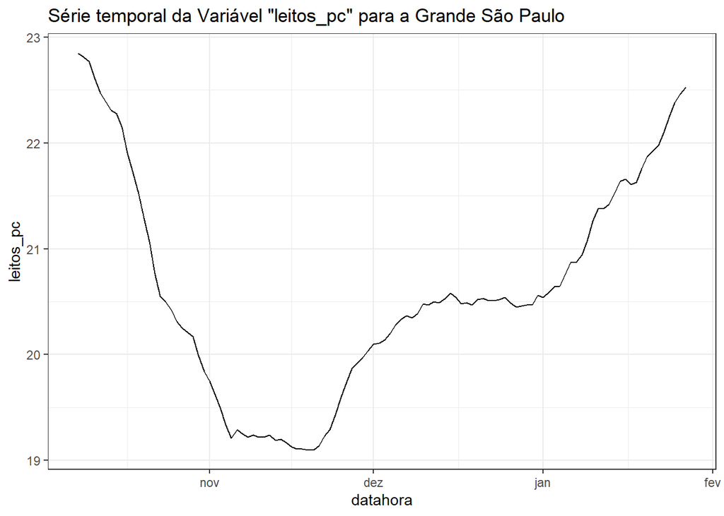

```r
leitos3 %>%
  filter(nome_drs=="DRS 01 Grande São Paulo") %>%
  ggplot(aes(x=datahora,y=leitos_pc))+
  geom_line()+
  ggtitle("Série temporal da Variável \"leitos_pc\" para a Grande São Paulo")+
  theme_bw()
```

Descrição: Número de novas internações (UTI e Enfermaria) de pacientes confirmados ou com suspeita de COVID-19 nos últimos 7 dias

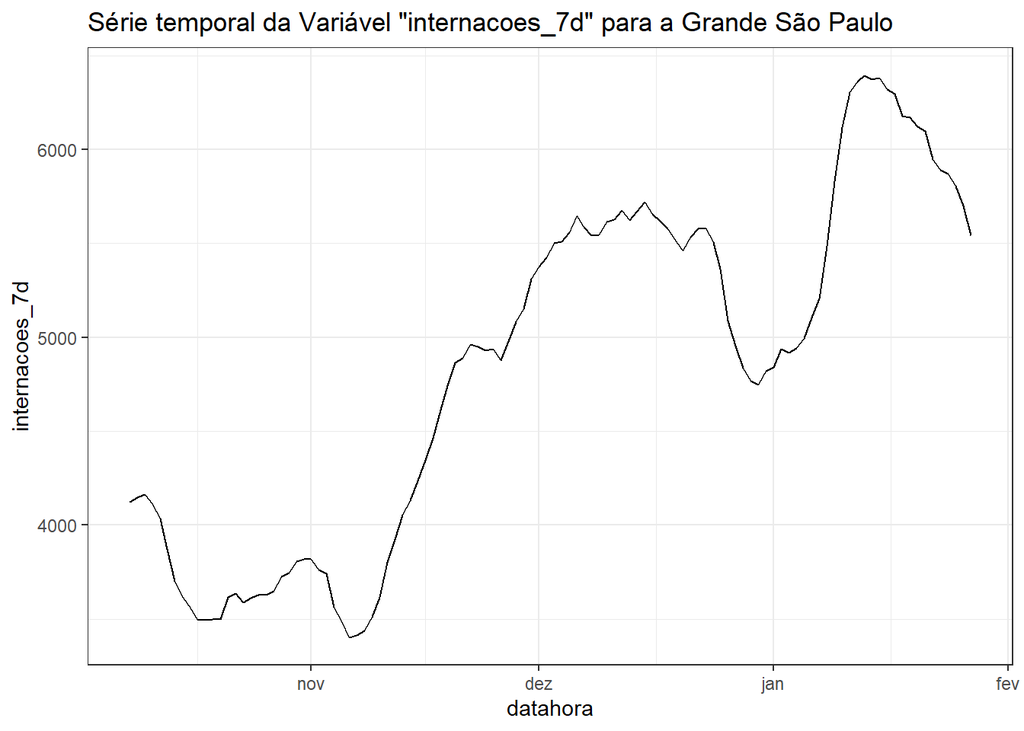

```r
leitos3 %>%
  filter(nome_drs=="DRS 01 Grande São Paulo") %>%
  ggplot(aes(x=datahora,y=internacoes_7d))+
  geom_line()+
  ggtitle("Série temporal da Variável \"internacoes_7d\" para a Grande São Paulo")+
  theme_bw()
```

## Variável internacoes_7d_l

Descrição: Número de novas internações (UTI e Enfermaria) de pacientes confirmados ou com suspeita de COVID-19 nos 7 dias anteriores.

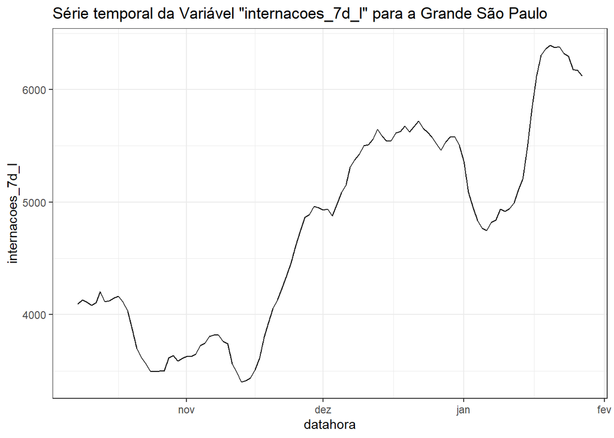

```r
leitos3 %>%
  filter(nome_drs=="DRS 01 Grande São Paulo") %>%
  ggplot(aes(x=datahora,y=internacoes_7d_l))+
  geom_line()+
  ggtitle("Série temporal da Variável \"internacoes_7d_l\" para a Grande São Paulo")+
  theme_bw()
```

## Variável internacoes_7v7

Descrição: Variação no número de novas internações ((internacoes_7d - internacoes_7d_l) / internacoes_7d_l)

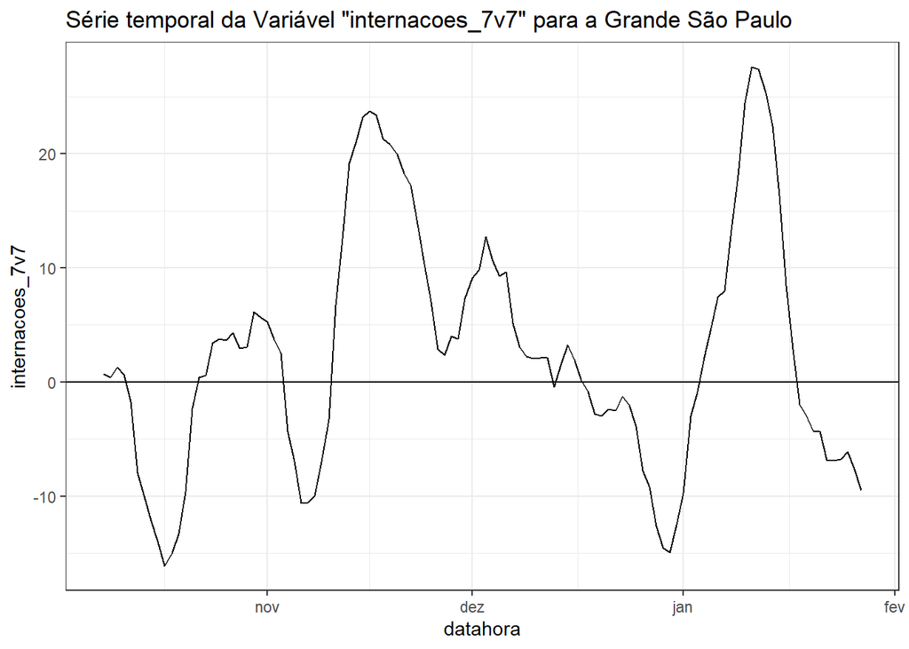

```r
leitos3 %>%
  filter(nome_drs=="DRS 01 Grande São Paulo") %>%
  ggplot(aes(x=datahora,y=internacoes_7v7))+
  geom_line()+
  ggtitle("Série temporal da Variável \"internacoes_7v7\" para a Grande São Paulo")+
  theme_bw()+
  geom_hline(yintercept = 0)
```

# Grandes Diferenças

- Começo das bases de dados a base leitos1(Série antiga (variação mensal)) e leitos3(Série em uso (variaçõa semanal e Grande São Paulo unificada)) começam de outubro enquanto a leitos2(Série antiga (variaçõa semanal)) começa no dia 19 de Maio.
- Todos banco de são diarios, suas colunas finais aparentam ter medidas semanais para as bases leitos2(Série antiga (variaçõa semanal)) e leitos3(Série em uso (variaçõa semanal e Grande São Paulo unificada)) enquanto leito1(Série antiga (variação mensal)) é mensal.
- A base de dados leitos2(Série antiga (variaçõa semanal)) dividi a grande são paulo em mais setores enquanto as outra consideram grande são paulo como um unico drs.